# w4111-F2020-Lecture_1a

COMS W4111: Introduction to Databases

Lecture 1: Introduction, Overview, Core Concepts

**Note:** Modifying width of cells for wider displays.

```python
from IPython.core.display import display, HTML
display(HTML("<style>.container { width:80% !important; }</style>"))
display(HTML("<style>.output_result { max-width:80% !important; }</style>"))
display(HTML("<style>.prompt { display:none !important; }</style>"))
```

**Note:**

This section meets once per week (F, 10:10 - 12:40) but each session is equivalent to two lectures in a twice per week course. That is, each session is two lectures. The format is:

- Lecture $n$
- Break
- Lecture $n+1$

This means that we will cover lectures 1 and 2 today.

- Lecture 1: 10:10 -- 11:25
- BREAK: 11:20 -- 11:30
- Lecture 2: 11:30 -- 12:40

# Lecture Agenda and Topics

1. Introduction:
   - Waitlist
   - Lecture structure
   - The course:
     - Objectives
     - Logistics
     - Assignments and grading
     - Course material
     - Outline/schedule
2. A quick demo of a use case/scenario that motivates databases management systems.  
   *Simple Analysis of COVID-19 Data and Projections.*
3. Overview of core concepts. (Textbook material, chapter 1 slides).
   - Data, databases
   - Database models
   - Database servers
   - Applications

# Introduction

## Waitlist

- The administrative staff of the Dept. of Computer Science **directly** manages enrollment in the W4111 sections and the wait lists.
  - COMS W4111 is **ALWAYS** oversubscribed and has huge wait lists.
  - The course is a requirement for several majors and tracks.
  - There are **complex rules** about prioritizing students for course enrollment, and also which students can take the hybrid section. (**Note:** The university has modified rules for online and hybrid classes for academic year 2020 - 2021).
- Contact the Dept. of Computer Science (Cynthia Meekins, cynthia@cs.columbia.edu) if you want to discuss the waitlist or enrollment. **You must work with the CS department if you have special circumstances for waitlist prioritization.**

## Lecture Format and Office Hours

- This is a hybrid section, like many classes this fall.
  - There will be *optional,* in-person lectures.
    - I will hold as many lectures in-person as possible but may hold some lectures online only.
    - I will announce in advance if I plan to hold a lecture online only.
  - Lectures are streamed and also recorded.
    - Students can attend in-person, watch the stream or watch the recording.
    - There are limitations on how many students can attend in person due to social distancing. I will provide a sign-up method to reserve seats.
- Office hours:
  - I will hold online offices hours.
  - I will be on campus when possible for students that want to speak with me or need more focused help.
    - I will publish in-person OH when I plan them.
    - I will provide a sign-up mechanism for in person office hours.
- **Note:**
  - Attendance in person is optional.
  - Please contact me if you experience any issues that require special consideration.
  - Your safety, your well-being and the well-being of your friends, family and community are always my primary concern.

## The Course: Description

- From the new/pending [Columbia University Bulletin](http://bulletin.columbia.edu/columbia-college/departments-instruction/computer-science/#coursestext)  
  "Prerequisites: COMS W3134, COMS W3136, or COMS W3137; or the instructor's permission.  
  The course covers what a database system is, how to design databases effectively and in a principled manner, how to query databases, and how to develop applications using databases: entity-relationship modeling, logical design of relational databases, relational algebra, SQL, database application development, database security, and an overview of query optimization and transaction processing. Additional topics generally include NoSQL, graph, object-relational, and cloud databases, as well as data preparation and cleaning of real-world data. **The course offers both programming and non-programming paths for homework and projects, to accommodate students with different programming skills and backgrounds.**" (NOTE: Emphasis Added)
- Prerequisites:
  - COMS W3134, COMS W3136, or COMS W3137 are data structures classes. All of these courses require extensive programming, in Java.
  - A course in data structures is helpful for **this** section of W4111 **but not essential.** I waive the requirement.
  - We will help you with any data structures knowledge you lack.
- Programming in/for this class:
  - There will be a "non-programming" option, which we will discuss below.
  - For students who want to take the programming track, we will use Python. I will provide motivation for choosing Python below.

## Assignments, Exams and Grades

- Point value of assignments and exams
  - 50%: Homework assignments: Approximately one HW every two weeks, for a total of 5.
  - Exams:
    - 20% of grade is midterm exam score.
    - 30% is final exam score.
  - A perfect sore of 100 points is **an A.** There are opportunities to get extra-credit.
- Non-programming track:
  - Homework:
    - Questions requiring written answers and diagrams.
    - Implement/execute/test of various database operations required to solve a use case/question.
    - Format will be a iPython/Jupyter Notebook.
  - Exams:
    - Obviously take home (this semester).
    - Same format and content as homework.
    - Tests understanding more broadly and deeply.
    - Students can access on-line material, textbooks, etc. to complete exams.
- Programming track:
  - Homework:
    - Will be a set of programming projects that build on prior projects.
    - We will build key elements of a simple application.
    - Will also include some written questions, but fewer than non-programming.
  - Exams:
    - All exams are take home exams.
    - Students can access on-line material, textbooks, etc. to complete exams.
    - Will be written answers to questions and some simple code sections.
    - Submission format will be iPython/Jupyter Notebook.
- Grading:
  - Based on total points in the range 0-100.
  - Perfect score is an A. A+ requires extra credit.
  - Extra-credit: Class participation, contributions on Piazza and office hour participation, extra work on assignments, etc. earn extra-credit points.
- Late submission
  - You have a total of 5 grace days to apply for all **homeworks.**
  - 1 minute past the due date counts for 1 day. 24 hours + 1 minute counts for two days.
  - You cannot use grace days for midterm, final exam or extra-credit assignments.
  - NOTE:
    - Respect for the individual is paramount.
    - We will always accommodate illness, family emergencies, etc.

## To Program or not to Program, That is the Question

- From the department's new guidance for the course:

"To accommodate the diverse backgrounds of the students who take this class, all sections of the class should include a non-programming option for projects and assignments. We (NOTE: Does not include me) have successfully offered such an option in some sections of the class for many years: students can either program a web application to interface with a DB of their own design, or alternatively follow the non-programming option and come up with a quantifiably more detailed DB design/data.

- What does not constitute programming?
  - Writing queries for a relational, graph, document, or other data management system does not constitute programming and can be expected of all students.
- What constitutes programming?
  - Reading more than a handful (1-5) lines of code_
  - Writing Python code that is not directly required to write a query."

Why I previous only did a programming track:

- Any non-trivial use of data and databases in any field requires programming. This is not Star Trek. You cannot shout, "Computer! Analyze ..."
- You might think, "But, I do not want to program. I want to go into financial services, private equity, ... I can just use tools like [Pandas.](https://pandas.pydata.org/)"
- "Wes McKinney started working on pandas in 2008 while at AQR Capital Management out of the need for a high performance, flexible tool to perform quantitative analysis on financial data."https://en.wikipedia.org/wiki/Pandas_(software) Even domain specific use of databases eventually requires some programming.
- Students in previous semester, including non-CS, eventually found the programming projects very helpful and impressed people during internship/job interviews.

The workload will be the same but the tasks different between the two tracks.

## Why Python

- The course description states Java. Why do you use Python?
- Python and the Python ecosystem are the dominant technology for working with data and databases.

| Python and Databases |
| --- |

| Python Ecosystem |
| --- |

- We will get some experience for both programming and non-programming tracks.

## Instructors

**Professor**

- Contact information:
  - Email: dff9@columbia.edu
  - Slack: https://dff-columbia.slack.com/
- Donald F. Ferguson
  - [Ansys, Inc.](https://www.ansys.com/): *Senior Technical Fellow, Chief Software Architect.*
  - *Adjunct Professor,* Dept. of Computer Science.
- Academic experience
  - Ph.D. in Computer Science, Columbia University, 1989.
  - Joined Columbia as full time *Professor of Professional Practice,* 01-Jan-2018.
  - Transitioned back to Adjunct Professor, 01-Jan-2019.
  - 13 semesters as an adjunct professor teaching
    - *E6998: Topics in Computer Science* or *E6156: Topics in SW Engineering*
      - Cloud Computing
      - Web and Internet Application Development
      - Web Application Servers and Applications
      - Microservices
      - Cloud: Backend as a Service
    - *W4111 - Introduction to Databases* (5 semesters)
  - *Professor of Professional Practice in Computer Science,* January 2018
    - *E1006 - Introduction to Computing for Engineers and Applied Scientists using Python*
    - *W4111 - Introduction to Databases*
    - *E6156 - Topics in SW Engineering: Microservices and Cloud Applications*
- 35 years industry experience
  - [IBM Fellow](https://en.wikipedia.org/wiki/IBM_Fellow), Chief Architect for IBM Software Group (https://en.wikipedia.org/wiki/IBM_Software_Group_(SWG)
  - Microsoft Technical Fellow
  - Executive Vice President, Distinguished Engineer, Chief Technology Officer, [CA Technologies](https://www.ca.com/us.html)
  - Vice President, CTO, Senior Technical Fellow, [Dell Software Group](https://en.wikipedia.org/wiki/Dell_Software)
  - Co-Founder and CTO, [Seeka TV](https://seekatv.com/)
  - Senior Technical Fellow, Chief SW Architect, [Ansys, Inc.](http://www.ansys.com)
- Publications
  - Approximately 60 technical publications.
  - Authored, co-authored several standards in web applications and web services.
  - *Web Services Platform Architecture: SOAP, WSDL, WS-Policy, WS-Addressing, WS-BPEL, WS-Reliable Messaging, and More,* ISBN-13: 978-0131488748, 2005, Pearson Education.
  - 12 patents.
- Personal and hobbies
  - Two amazing children (One is a 2020 Barnard graduate. One is a freshman in collete).
  - Interested in languages. Speak Spanish reasonably well and trying to learn Arabic.
  - Black Belt in Kenpo Karate
  - Amateur astronomy
  - Road bicycling
  - Officer in the New York Guard

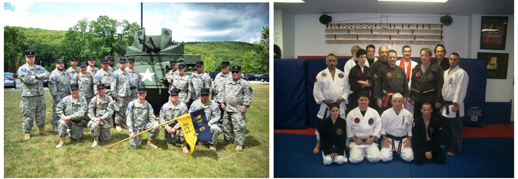

**Course/Instruction Assistants**

We have great CAs/IAs. They will announce on Piazza.

- CA/IA from previous semesters (most also took the class with me):
  - Ara Petersen
  - Carrie Haw Kellar
  - Georgia Liu
  - Yiwen Gao
- CA/IA who have taken the class from me.
  - Emily Arroyo
  - Ohla Maslova
  - Swapnav Deka
- We will likely get a couple more TAs.
- Piazza for the course has [calendar](https://piazza.com/class/kd7mco27ygz5ew?cid=12) of office hours.

## About this Course

### Value

- This course is foundational, and will teach you the core concepts in
  - Data modeling
  - Data model implementation; Data manipulation.
  - Different database models and database management systems.
  - Implementation and architecture of data centric applications and database management systems.
- ANY non-trivial application
  - Requires a well-designed data model.
  - Implements a data model and manipulates data.
  - Uses a database management system.
- Understanding databases and database management is core to the “hottest fields” in computer science, e.g.
  - Data science
  - Machine learning
  - Intelligent (Autonomous) systems
  - Internet-of-Things
  - Cybersecurity
  - Cloud Computing
- Database, database application, etc. skills are increasingly central to many disciplines, including economics, IEOR, mechanical and electrical engineering, business and finance, ...
- University courses on databases sometimes focus on theory and abstract concepts. This course will cover theory, but there will be an increased emphasis on:
  - Practical, hands-on applications of databases.
  - Developing and understanding database centric applications (programming track).
  - Patterns and best practices.
- __Personal perspective__
  - A large percent of my career has been spent figuring out or leading teams that figured out how to model, implement and manipulate data.
  - I have used the information in this class more than anything else I have learned.
  - This will likely be true for you.

### Course Objectives

- Have fun, learn a lot and come to appreciate and enjoy some amazing technology.
- Provide a foundation that allows you to succeed in future courses. This is an *introduction* to databases. The technology is crucial for future courses
  - Advanced database classes
  - Machine learning
  - Big data, data analysis
  - Numerical, simulation and analytics in operations research, engineering, economics, finance, life sciences, etc.
- Enable you to successfully apply the technology in your work and profession.

Have cool stuff to talk about on interviews and in your resumes.

### Organization and Logistics

- Lecture: Friday, 10:10 AM-12:40 PM, Room TBD
- Instructor: Donald F. Ferguson (dff@cs.columbia.edu)
- Office Hours:
  - Fridays: 8:30 AM - 10:00 PM, 1:00 - 2:00 PM, 4:00 PM - 6:00 PM.
    - Location TBD
    - Will hold on-line office hours.
  - By appointment, as needed, as available.
  - I hold a lot of extra office hours, usually on weekends.
    - I typically post on Piazza when I will have extra availability.
    - The extra OHs may be "recitations," in which I go over exam questions, homework, etc.
    - Extra OH and recitations are often on the weekend or in the evening.
  - I will be flexible about timezones for extra office hours to accommodate students.
- **Recitation Section R02:** This is an optional recitation/office hours. It will be in person (when possible) and on-line. You do not need to register for it.
- Collaboration/Contact/Content:
  - The class is on [Piazza](https://piazza.com/class/kd7mco27ygz5ew)
    - General questions
    - Clarification of homeworks, class material, etc.
  - The course lectures, sample code, etc. will be on GitHub.
    - GitHub home page (https://donald-f-ferguson.github.io/IntroductionToDatabases_F20/)
    - Repository/Project (https://github.com/donald-f-ferguson/IntroductionToDatabases_F20)
  - Course Assistants: See above
  - There is a [Slack Team/Group](https://join.slack.com/t/dff-columbia/shared_invite/zt-3mnfb5it-MaZbLZRd9vGg06M5ueC8Zw) for my courses. Please join the channel `w4111-f2w.`

### Environment and material

- Primary content is in lectures and references.
- Recommended textbook:
  - **Database System Concepts 7th Edition,**, Abraham Silberschatz, Henry Korth, S. Sudarshan. ISBN-13: 978-0078022159
  - We will cover a subset of the material in the textbook, and in a different order.
  - There is a [website](https://www.db-book.com/db7/index.html) for the book that has PowerPoint, samples, etc.
- I will bring in examples from industry, engineering and practical experience.
- Lecture material and examples:
  - Will be Jupyter Notebooks (http://jupyter.org/) and PowerPoint for most lectures. I usually install the full [Anaconda suite.](https://www.anaconda.com/download)
  - There is a site associated with the textbook that contains the slides, database schema, examples, etc. (https://www.db-book.com/db7/).
  - Notebooks, slides, sample code, etc. will be available on [GitHub project](https://github.com/donald-f-ferguson/IntroToDatabases_F20) for the course. The easiest approach is to clone the project repository.

### Programming and Non-Programming

- Programming Track: Project and development;
  - We will use Python.
  - Database engines and tools
    - We will start with the relational data model. Please install the latest versions of
      - [MySQL](https://dev.mysql.com/downloads/mysql/)
      - [MySQL Workbench](https://dev.mysql.com/downloads/mysql/).
    - We will also use [Neo4j](https://neo4j.com/), [CouchDB](http://couchdb.apache.org/) and Redis (https://redis.io/), but you do not need to install now.
    - I will try to cover [DynamoDB](https://aws.amazon.com/dynamodb/), [DocumentDB](https://aws.amazon.com/documentdb/) and [Firebase Realtime Database](https://firebase.google.com/docs/database/), which are cloud DBs.
  - [Integrated Development Environments](https://en.wikipedia.org/wiki/Integrated_development_environment) for the *programming track.*
    - The [JetBrains](https://www.jetbrains.com/student/) tools are free for students, and useful for Python, JavaScript and Java. **I strongly recommend you use an IDE developing code.** Install the **Professional Edition** and get a free student license.
- Non-programming track:
  - I am trying to arrange for you to not have to install (too much) SW.
  - Installing the MySQL stuff is probably a good idea but not necessary.
  - Net: You do not have to install anything right now, other than Anaconda.
  - You will work with the same set of databases, e.g. relational, Neo4j, ...
- Both Tracks: I will use Ananconda/Jupyter for most of the lectures and examples. You MUST to install
  - Install Python 3
  - [Anaconda Community Distribution](https://www.anaconda.com/distribution)
  - Ananconda includes the [Spyder](https://github.com/spyder-ide/spyder), PyCharm and VisualStudio for Python. I **strongly** prefer JetBrains but you can use VisualStudio.
  - The IDE will be useful for non-programming track but not necessary.
- My normal development approach is:
  - Develop and test code using PyCharm (IDE)
  - Copy into Notebook when "done.
  - Debugging is very hard without a good IDE debugger.
  - I suggest you do the same and use PyCharm.

In lectures, I will provide links to on-line material providing definitions and optional information. I often use Wikipedia because it is a good starting point and has many references.

### Course Outline

#### Modules

**Module I: Foundational Concepts**

1. Introduction to databases, role in applications, type of DB applications and overall system software architecture.
2. Information and data modeling and best practices, focusing on supporting application scenarios.
3. Relational data model (theory), Relational Database Management Systems, Structured Query Language, data query and update scenarios.
4. Extended topics in SQL and RDBMS (performance, security, constraints, triggers, connection management, etc).

**Module II: Database Management System Implementation/Architecture**

1. Storage management, disk management, buffer management, indexes.
2. Query processing and optimization: Query evaluation, query parsing and parse trees, operator implementation algorithms, query rewrite, query optimization techniques.
3. Concurrency control and transaction management.

**Module III: NoSQL Database Overview**

1. Overview, graph databases, key-value databases, document databases.
2. Amazon S3, Amazon DynamoDB, Google Firebase/Cloud Firestore.

**Module IV: Decision Support, Data Analysis**

1. Overview of schema denormalization, OLAP cubes, data analytics, machine learning.

# One Quick Motivating Demo

## COVID-19 Data

- [Institute for Health Metrics and Evaluation (IHME)](http://www.healthdata.org/about) is one of the most referenced sites for data and projections on COVID-19.

| **IHME Overview** |
| --- |

- How does a web site like this work?

| **IHME Overview** |
| --- |

| [Web Application Architecture](https://reinvently.com/blog/fundamentals-web-application-architecture/) |
| --- |

1. An "application" runs in the browser:
   - JavaScript code.
   - Static content for text, images, forms, etc.
   - User actions cause API calls to retrieve data and update display.
2. There is a web server that delivers that static content using URLs.
3. Programmers developed an application in Python, JavaScript, Java, ... ... that:
   - Receives API calls.
   - Access a "database" to retrieve requested data.
   - Formats and returns requested data to the browser.
- This course covers the database aspects of many types of applications.
- Other courses cover web applications, user interface/user experience, ... ...

## "Simple" Database Examples

### Getting the Data

- You can [manually download](http://www.healthdata.org/covid/data-downloads) the data in Zip files containing comma separate value [(CSV) format.](https://en.wikipedia.org/wiki/Comma-separated_values) CSV files are an extremely common form of sharing and distributing data between organizations and teams.
- CSV file is an common exchange format for Excel spreadsheets, Google Sheets, ... ...

| **IHME Downloaded Files** |
| --- |

- There are "read me" files explaining what is in the files.

| **IHME Read Me Files** |
| --- |

- The data is basically of the form:
  - "Our data/projections on this date ..." (Folder Name)
  - Is in this file. (CSV file name)

| **IHME Downloaded Files** |
| --- |

- Approximately 35 downloads. For each download, CSV file format:
  - Approximately 40 columns.
  - Approximately 50K rows.
- This seems like a lot of data, but is really a tiny dataset. We will see some large examples later.
- Consider a specific variable, e.g. `deaths_mean.` The format is
  - "On $<belief date>$, we $ <observed|projected> $"
  - "that the `deaths_mean` on $<value date>$ was/would be $<value>$"
  - "in location $<location>$."
- The was a little confusing, put in prose. "We gathered data and ran our models on 2020-Aug-18. On this date, the reported number of deaths in NY City on May 23 was 11. The projected/predicted number of deaths on Dec. 1 is 35."
- This can result in some interesting queries, "On 12-JUN, how many deaths did we predict for NY City on 13-OCT?"
- There are a couple of issues with the data:
  - The `belief date` is in the folder name, and not in a column in the file.
  - For unknown reasons, there is `location name` that is usually the name of a state/province, but does not include the country.
  - The site changed the formats of the files over time.
- I had to write some icky, but not too complex Python code to clean up, standardize and load the data into a relational databases. I will share the code with you if you are interested. But, it is icky, quick and awful code.

| **IHME Load Progress Files** |
| --- |

- Data loading, cleanup, etc. is extremely common in all aspects of using databases.

### Some Simple Queries

- [MySQL](https://www.mysql.com/) is an SQL [relational database](https://en.wikipedia.org/wiki/Relational_database) product. We will cover this technology in detail.
- I am going to install a [Jupyter/iPython Magic](https://www.tutorialspoint.com/jupyter/ipython_magic_commands.htm) to help with SQL. The plug-in is [iPython SQL.](https://pypi.org/project/ipython-sql/)

```python
import pymysql
%load_ext sql
%sql mysql+pymysql://root:dbuserdbuser@localhost/AAF20W4111
```

```
'Connected: root@AAF20W4111'
```

**How Many Entries in the Table**?

```python
q_result = %sql select count(*) as count from ihme
no_rows = q_result[0]["count"]
print("\n\nThere are", round(no_rows/1000000.0,2), "million rows in the database.\n")
```

```
 * mysql+pymysql://root:***@localhost/AAF20W4111
1 rows affected.


There are 1.5 million rows in the database.
```

**What is the Maximum Number of Predicted Deaths for the United States of America?**

```python
q_result = %sql select max(totdea_mean) as oh_darn from ihmefast where location_name = "United States of America"
oh_darn = q_result[0]["oh_darn"]
print("\n\nThe worst prediction for the US total deaths is", round(oh_darn,0), "\n")
```

```
 * mysql+pymysql://root:***@localhost/AAF20W4111
1 rows affected.


The worst prediction for the US total deaths is 295011.0
```

- SQL statement: `select max(totdea_mean) as oh_darn from ihmefast where location_name = "United States of America"`
- What does that statement mean?
  - Scan all rows in the database table.
  - For all rows with column named `location_name` with value "United States of America"
  - Find the maximum value for the columna `totdea_mean.`

**Which Location has the Worst Predicted Deaths?**

```python
%sql select location_name, round(max(totdea_mean), 0) as total_deaths from ihmefast group by location_name order by total_deaths desc limit 10;
```

```
 * mysql+pymysql://root:***@localhost/AAF20W4111
10 rows affected.
```

| location_name | total_deaths |
| --- | --- |
| Brazil | 383118.0 |
| United States of America | 295011.0 |
| Mexico | 118810.0 |
| Mexico_country | 99418.0 |
| US | 93765.0 |
| Sao Paulo | 72475.0 |
| Iran (Islamic Republic of) | 71548.0 |
| United Kingdom | 68367.0 |
| Philippines | 55498.0 |
| Russian Federation | 55314.0 |

**How has Maximum Death Prediction for USA Changed over Time?**

```python
%%sql

select belief_date, round(max(totdea_mean), 0) as total_deaths from ihmefast
    where location_name="United States of America"
    group by belief_date order by belief_date;
```

```
 * mysql+pymysql://root:***@localhost/AAF20W4111
30 rows affected.
```

| belief_date | total_deaths |
| --- | --- |
| 2020-03-26 | 81114.0 |
| 2020-03-27 | 81114.0 |
| 2020-03-29 | 82141.0 |
| 2020-04-05 | 81766.0 |
| 2020-04-07 | 60415.0 |
| 2020-04-09 | 61545.0 |
| 2020-04-12 | 68841.0 |
| 2020-04-16 | 60308.0 |
| 2020-04-20 | 65976.0 |
| 2020-04-21 | 67641.0 |
| 2020-04-26 | 74073.0 |
| 2020-04-27 | 72860.0 |
| 2020-04-28 | 72433.0 |
| 2020-05-04 | 134475.0 |
| 2020-05-08 | 137184.0 |
| 2020-05-10 | 147040.0 |
| 2020-05-19 | 143357.0 |
| 2020-05-23 | 143357.0 |
| 2020-05-28 | 135109.0 |
| 2020-06-03 | 150176.0 |
| 2020-06-06 | 145728.0 |
| 2020-06-08 | 169890.0 |
| 2020-06-13 | 201129.0 |
| 2020-06-24 | 179106.0 |
| 2020-06-27 | 175168.0 |
| 2020-07-04 | 208255.0 |
| 2020-07-11 | 224089.0 |
| 2020-07-18 | 219864.0 |
| 2020-07-26 | 230822.0 |
| 2020-08-06 | 295011.0 |

- That was a little hard to follow. Can we do a chart?

```python
import numpy as np
import pandas as pd
import matplotlib.pyplot as plt
```

```python
%%sql d_info << select belief_date, round(max(totdea_mean), 0) as total_deaths from ihmefast
    where location_name="United States of America"
    group by belief_date order by belief_date;
```

```
 * mysql+pymysql://root:***@localhost/AAF20W4111
30 rows affected.
Returning data to local variable d_info
```

```python
df = pd.DataFrame(d_info)
df.columns = ['Belief Date', 'Total Deaths']
df
```

|  | Belief Date | Total Deaths |
| --- | --- | --- |
| 0 | 2020-03-26 | 81114.0 |
| 1 | 2020-03-27 | 81114.0 |
| 2 | 2020-03-29 | 82141.0 |
| 3 | 2020-04-05 | 81766.0 |
| 4 | 2020-04-07 | 60415.0 |
| 5 | 2020-04-09 | 61545.0 |
| 6 | 2020-04-12 | 68841.0 |
| 7 | 2020-04-16 | 60308.0 |
| 8 | 2020-04-20 | 65976.0 |
| 9 | 2020-04-21 | 67641.0 |
| 10 | 2020-04-26 | 74073.0 |
| 11 | 2020-04-27 | 72860.0 |
| 12 | 2020-04-28 | 72433.0 |
| 13 | 2020-05-04 | 134475.0 |
| 14 | 2020-05-08 | 137184.0 |
| 15 | 2020-05-10 | 147040.0 |
| 16 | 2020-05-19 | 143357.0 |
| 17 | 2020-05-23 | 143357.0 |
| 18 | 2020-05-28 | 135109.0 |
| 19 | 2020-06-03 | 150176.0 |
| 20 | 2020-06-06 | 145728.0 |
| 21 | 2020-06-08 | 169890.0 |
| 22 | 2020-06-13 | 201129.0 |
| 23 | 2020-06-24 | 179106.0 |
| 24 | 2020-06-27 | 175168.0 |
| 25 | 2020-07-04 | 208255.0 |
| 26 | 2020-07-11 | 224089.0 |
| 27 | 2020-07-18 | 219864.0 |
| 28 | 2020-07-26 | 230822.0 |
| 29 | 2020-08-06 | 295011.0 |

```python
plt.figure(figsize=(40,20))
ax = df.plot(x='Belief Date', y='Total Deaths', figsize=(20,10))
ax.set_ylabel('Total Deaths')
```

[figure not shown]

- Can I get some information per state? Well, this requires me to know which locations are states, which are countries and what states are in what countries.
- This information is not in the IHME database.

**What Locations do I Know About?**

```python
import time
start_time = time.time()

# This is the actual statement. The rest is just timing it.
res = %sql select distinct location_name from ihmefast


elapsed_time = time.time() - start_time
print("Distinct locations are: \n", res)
print("Total elapsed time = ", round(elapsed_time, 3), "seconds")
```

```
 * mysql+pymysql://root:***@localhost/AAF20W4111
358 rows affected.
Distinct locations are:
 +--------------------------------------------------------------+
|                        location_name                         |
+--------------------------------------------------------------+
|                           Abruzzo                            |
|                             Acre                             |
|                         Afghanistan                          |
|                        Aguascalientes                        |
|                           Alabama                            |
|                           Alagoas                            |
|                            Alaska                            |
|                           Albania                            |
|                           Alberta                            |
|                           Algeria                            |
|                            Amapa                             |
|                           Amazonas                           |
|                          Andalucia                           |
|                           Andorra                            |
|                            Angola                            |
|                     Antigua and Barbuda                      |
|                            Aragon                            |
|                          Argentina                           |
|                           Arizona                            |
|                           Arkansas                           |
|                           Armenia                            |
|                           Asturias                           |
|                          Australia                           |
|                           Austria                            |
|                     Azad Jammu & Kashmir                     |
|                          Azerbaijan                          |
|                      Baden-Wurttemberg                       |
|                           Bahamas                            |
|                            Bahia                             |
|                           Bahrain                            |
|                       Baja California                        |
|                     Baja California Sur                      |
|                       Balearic Islands                       |
|                         Balochistan                          |
```

[output cut: 311 more lines]

```
|               Veracruz de Ignacio de la Llave                |
|                           Vermont                            |
|                           Virginia                           |
|                          Washington                          |
|                        West Virginia                         |
|                          Wisconsin                           |
|                           Wyoming                            |
|                            Yemen                             |
|                           Yucatan                            |
|                            Yukon                             |
|                          Zacatecas                           |
|                            Zambia                            |
|                           Zimbabwe                           |
+--------------------------------------------------------------+
Total elapsed time =  0.005 seconds
```

- SQL statement: `select distinct location_name from ihmefast`
- Is equivalent to the following code, which I ran against a CSV with all of the records.

```python
import csv

def get_distinct_column_values(f_name, col_name, trace_count=0):

    result = set()
    rows_read = 0

    with open(f_name, "r") as in_file:

        result = set()

        csv_file = csv.DictReader(in_file)

        for r in csv_file:
            rows_read += 1
            if trace_count > 0 and rows_read % trace_count == 0:
                print("Have read ", rows_read, "rows.")

            val = r.get(col_name, None)
            if val is not None:
                result.add(val)

    return result
```

- Let's do a timed run of the code that I wrote against a single CSV file that contains all of the entries.

```python
d_file = "/Users/donaldferguson/Dropbox/Columbia/Courses/W4111F2020/IntroductionToDatabases_F20/Data/ihmefast.csv"
start_time = time.time()
res = get_distinct_column_values(d_file, "location_name", 0)
elapsed_time = time.time() - start_time
print("Distinct locations are: \n")
for r in res:
    print(r)
print("\n\notal elapsed time = ", round(elapsed_time, 3), "seconds")
```

```
Distinct locations are:

Azerbaijan
Ceará
South Dakota
Toscana
Aragon
Benin
Coahuila
Prince Edward Island
Nunavut
Luxembourg
State of Mexico
Bahrain
Quintana Roo
Nevada
Tennessee
Emilia-Romagna
Saxony-Anhalt
Ireland
San Luis Potosi
Durango
Colorado
Florida
Iceland
Utah
Portugal
Maldives
Barbados
Baja California
Mali
Arkansas
Michigan
Baja California Sur
Republic of Moldova
Spain
Trinidad and Tobago
Togo
Roraima
Andorra
```

[output cut: 326 more lines]

```
Louisiana
Campeche
Chihuahua
Kyrgyzstan
Maryland
Estonia
Castile and Leon
Belarus
Lombardia
United States Virgin Islands
Zambia
Montenegro


otal elapsed time =  18.983 seconds
```

- Some observations:
  - The SQL statement was a lot more compact and simple.
  - The execution time was about 4,000 times faster.
- We will understand the power of using databases systems in this class.
  - Specialize "query languages."
  - Performance optimization for data centric applications.

## Country, Region, City Information

- I did some exploration. There are several types of location names:
  - Countries
  - "States" within countries.
  - Other "things" in states: cities, specific hot spots (e.g. nursing homes), etc.
- How do I know what is what? Well, there are also on-line sources of information on countries, regions, ... ...
- There are downloadable sources of information about country, city, state, etc.
- I used the data from a [GitHub project.](https://github.com/dr5hn/countries-states-cities-database) I loaded into a MySQL database server on my laptop. The data is 3 files:
  - `cities`
  - `states`
  - `countries`
  - And linked by IDs in the files.
- What does the location information look like?
- One way to represent information about the data (known as [metadata](https://en.wikipedia.org/wiki/Metadata)) is to use an [Entity Relationship Diagram](https://en.wikipedia.org/wiki/Entity%E2%80%93relationship_model).

| **An Example ER Diagram** |
| --- |

- We will learn about ER diagrams and modeling in this course.
- What are some things that I can do with the data?
- What are the cities in Massachusetts?

```python
%%sql ma_towns <<
        select * from
            (select
                countries.name as country_name, countries.iso2 as country_code,
                cities.name as city_name,
                (select states.name as state_name from states where
                     states.id=cities.state_id) as state_name
                from
                    countries join cities on countries.id = cities.country_id) as b
        where state_name='Massachusetts';
```

```
 * mysql+pymysql://root:***@localhost/AAF20W4111
404 rows affected.
Returning data to local variable ma_towns
```

```python
print("The towns in MA are ... ...")
print(ma_towns)
```

```
The towns in MA are ... ...
+---------------+--------------+---------------------------+---------------+
|  country_name | country_code |         city_name         |   state_name  |
+---------------+--------------+---------------------------+---------------+
| United States |      US      |          Abington         | Massachusetts |
| United States |      US      |           Acton           | Massachusetts |
| United States |      US      |          Acushnet         | Massachusetts |
| United States |      US      |      Acushnet Center      | Massachusetts |
| United States |      US      |           Adams           | Massachusetts |
| United States |      US      |           Agawam          | Massachusetts |
| United States |      US      |          Amesbury         | Massachusetts |
| United States |      US      |          Amherst          | Massachusetts |
| United States |      US      |       Amherst Center      | Massachusetts |
| United States |      US      |          Andover          | Massachusetts |
| United States |      US      |         Arlington         | Massachusetts |
| United States |      US      |         Ashburnham        | Massachusetts |
| United States |      US      |           Ashby           | Massachusetts |
| United States |      US      |          Ashfield         | Massachusetts |
| United States |      US      |          Ashland          | Massachusetts |
| United States |      US      |          Assonet          | Massachusetts |
| United States |      US      |           Athol           | Massachusetts |
| United States |      US      |         Attleboro         | Massachusetts |
| United States |      US      |           Auburn          | Massachusetts |
| United States |      US      |            Avon           | Massachusetts |
| United States |      US      |            Ayer           | Massachusetts |
| United States |      US      |        Baldwinville       | Massachusetts |
| United States |      US      |         Barnstable        | Massachusetts |
| United States |      US      |     Barnstable County     | Massachusetts |
| United States |      US      |           Barre           | Massachusetts |
| United States |      US      |           Becket          | Massachusetts |
| United States |      US      |          Bedford          | Massachusetts |
| United States |      US      |        Belchertown        | Massachusetts |
| United States |      US      |         Bellingham        | Massachusetts |
| United States |      US      |          Belmont          | Massachusetts |
| United States |      US      |          Berkley          | Massachusetts |
| United States |      US      |      Berkshire County     | Massachusetts |
| United States |      US      |           Berlin          | Massachusetts |
| United States |      US      |        Bernardston        | Massachusetts |
| United States |      US      |          Beverly          | Massachusetts |
| United States |      US      |        Beverly Cove       | Massachusetts |
```

[output cut: 354 more lines]

```
| United States |      US      |          Whitman          | Massachusetts |
| United States |      US      |         Wilbraham         | Massachusetts |
| United States |      US      |        Williamsburg       | Massachusetts |
| United States |      US      |        Williamstown       | Massachusetts |
| United States |      US      |         Wilmington        | Massachusetts |
| United States |      US      |         Winchendon        | Massachusetts |
| United States |      US      |         Winchester        | Massachusetts |
| United States |      US      |          Winthrop         | Massachusetts |
| United States |      US      |           Woburn          | Massachusetts |
| United States |      US      |         Worcester         | Massachusetts |
| United States |      US      |      Worcester County     | Massachusetts |
| United States |      US      |          Wrentham         | Massachusetts |
| United States |      US      |          Yarmouth         | Massachusetts |
| United States |      US      |       Yarmouth Port       | Massachusetts |
+---------------+--------------+---------------------------+---------------+
```

## An Example of Data From Several Sources: IHME and Geography

- What are the state names in the United States? I happen to know the country code.

```python
%sql select name from states where country_code="US"
```

```
 * mysql+pymysql://root:***@localhost/AAF20W4111
66 rows affected.
```

| name |
| --- |
| Howland Island |
| Delaware |
| Alaska |
| Maryland |
| Baker Island |
| Kingman Reef |
| New Hampshire |
| Wake Island |
| Kansas |
| Texas |
| Nebraska |
| Vermont |
| Jarvis Island |
| Hawaii |
| Guam |
| United States Virgin Islands |
| Utah |
| Oregon |
| California |
| New Jersey |
| North Dakota |
| Kentucky |
| Minnesota |
| Oklahoma |
| Pennsylvania |
| New Mexico |
| American Samoa |
| Illinois |
| Michigan |
| Virginia |
| Johnston Atoll |
| West Virginia |
| Mississippi |
| Northern Mariana Islands |
| United States Minor Outlying Islands |
| Massachusetts |
| Arizona |
| Connecticut |
| Florida |
| District of Columbia |
| Midway Atoll |
| Navassa Island |
| Indiana |
| Wisconsin |
| Wyoming |
| South Carolina |
| Arkansas |
| South Dakota |
| Montana |
| North Carolina |
| Palmyra Atoll |
| Puerto Rico |
| Colorado |
| Missouri |
| New York |
| Maine |
| Tennessee |
| Georgia |
| Alabama |
| Louisiana |
| Nevada |
| Iowa |
| Idaho |
| Rhode Island |
| Washington |
| Ohio |

- So, let's find the maximum deaths per state in the US.

```python
%%sql select location_name, round(max(totdea_mean),0) as total_deaths from ihmefast where
    location_name in (select name from states where country_code="US")
    group by location_name order by total_deaths desc
```

```
 * mysql+pymysql://root:***@localhost/AAF20W4111
54 rows affected.
```

| location_name | total_deaths |
| --- | --- |
| New York | 35379.0 |
| California | 32692.0 |
| Texas | 27435.0 |
| Florida | 19358.0 |
| New Jersey | 18734.0 |
| Massachusetts | 12906.0 |
| Pennsylvania | 12420.0 |
| Georgia | 11288.0 |
| Illinois | 9995.0 |
| Ohio | 9041.0 |
| North Carolina | 8862.0 |
| Michigan | 8771.0 |
| Arizona | 7946.0 |
| Louisiana | 7901.0 |
| Alabama | 7334.0 |
| Indiana | 6248.0 |
| Virginia | 5842.0 |
| Colorado | 5795.0 |
| Connecticut | 5474.0 |
| Missouri | 5436.0 |
| Maryland | 5219.0 |
| Washington | 5075.0 |
| Tennessee | 4985.0 |
| South Carolina | 4556.0 |
| Wisconsin | 3708.0 |
| Mississippi | 3464.0 |
| Minnesota | 3191.0 |
| Nevada | 3152.0 |
| Maine | 3013.0 |
| Oregon | 2992.0 |
| Oklahoma | 2967.0 |
| Kentucky | 2941.0 |
| Iowa | 2331.0 |
| Puerto Rico | 2259.0 |
| Kansas | 2245.0 |
| Arkansas | 2234.0 |
| Nebraska | 1949.0 |
| New Mexico | 1634.0 |
| Rhode Island | 1334.0 |
| Utah | 1292.0 |
| Idaho | 916.0 |
| Delaware | 827.0 |
| New Hampshire | 792.0 |
| District of Columbia | 718.0 |
| North Dakota | 677.0 |
| West Virginia | 543.0 |
| Montana | 521.0 |
| Hawaii | 398.0 |
| Vermont | 386.0 |
| South Dakota | 356.0 |
| Alaska | 315.0 |
| Wyoming | 243.0 |
| United States Virgin Islands | 52.0 |
| Guam | 6.0 |

- What did the database engine do to produce the result?

| **Example Query Plan** |
| --- |

- Basically and overly simplistically, the query engine parses and compiles the SQL statement into code to run the query. The process looks is:

| **An Example ER Diagram** |
| --- |

- You will learn in this course how database engines perform these functions.

### Example Summary

- You are probably thinking ... "What did he just do? How did he just do it?"

| **Would You Like to Be a Wizard?** |
| --- |

- You will be a wizard by the end of the semester.
- Well, if you take the programming track. If you take the non-programming track, you may still be a muggle. Just kidding.

| **Muggles** |
| --- |

# Lecture Slides

- Switch to lecture slides.

# Let's Play with the Database!

## The Database Schema

| **Sample Database: Database Systems Concepts** |
| --- |

## Some Queries

**Who are the students?**

```python
# Use the course example database. This is similar to changing to a directory that contains files.
%sql use aaBookDB;
```

```
 * mysql+pymysql://root:***@localhost/AAF20W4111
0 rows affected.
```

```
[]
```

```python
%sql select * from student;
```

```
 * mysql+pymysql://root:***@localhost/AAF20W4111
13 rows affected.
```

| ID | name | dept_name | tot_cred |
| --- | --- | --- | --- |
| 00128 | Zhang | Comp. Sci. | 102 |
| 12345 | Shankar | Comp. Sci. | 32 |
| 19991 | Brandt | History | 80 |
| 23121 | Chavez | Finance | 110 |
| 44553 | Peltier | Physics | 56 |
| 45678 | Levy | Physics | 46 |
| 54321 | Williams | Comp. Sci. | 54 |
| 55739 | Sanchez | Music | 38 |
| 70557 | Snow | Physics | 0 |
| 76543 | Brown | Comp. Sci. | 58 |
| 76653 | Aoi | Elec. Eng. | 60 |
| 98765 | Bourikas | Elec. Eng. | 98 |
| 98988 | Tanaka | Biology | 120 |